# Preparing Spatial Data

Divyashree Rana

2026-07-05

# 1 Load required packages

The following package is required for raster processing, moving window analyses, and exporting resistance surfaces for subsequent optimization.

```r
library(terra)
```

# 2 Load 1 km raster surfaces

Environmental predictor rasters are first imported at their native 1 km resolution from Google Earth Engine and stored in ./input/rasters_1km. These rasters serve as the baseline inputs from which coarser-scale representations are generated using moving window smoothing. This allows rasters processed at different spatial scales to have same resolution and still mergeable for multisurface optimization.

## 2.1 Import raster layers

```r
raster_dir <- "./input/rasters_1km"

files <- list.files(
  raster_dir,
  pattern = "\\.asc$",
  full.names = TRUE
)

files
```

```
## [1] "./input/rasters_1km/agri_dens_1km.asc"
## [2] "./input/rasters_1km/agri_dens_1km_1km.asc"
## [3] "./input/rasters_1km/dist_settlement_10m_utm_1km.asc"
## [4] "./input/rasters_1km/dist_settlement_10m_utm_1km_1km.asc"
## [5] "./input/rasters_1km/dist_water_30m_utm_1km.asc"
## [6] "./input/rasters_1km/dist_water_30m_utm_1km_1km.asc"
## [7] "./input/rasters_1km/MODIS_EVI_rescaled_500m_utm_1km.asc"
## [8] "./input/rasters_1km/MODIS_EVI_rescaled_500m_utm_1km_1km.asc"
```

```r
rasters <- rast(files)

rasters
```

```
## class       : SpatRaster
## size        : 113, 169, 8  (nrow, ncol, nlyr)
## resolution  : 1000, 1000  (x, y)
## extent      : 381000, 550000, 3074000, 3187000  (xmin, xmax, ymin, ymax)
## coord. ref. : WGS 84 / UTM zone 44N
## sources     : agri_dens_1km.asc
##               agri_dens_1km_1km.asc
##               dist_settlement_10m_utm_1km.asc
##               ... and 5 more sources
## names       : agri_~s_1km, agri_~s_1km, dist_~m_1km, dist_~m_1km, dist_~m_1km,  dist_~m_1km, ...
## min values  :          ? ,           0,          ? ,    5.413951,          ? , 5.526969e-03, ...
## max values  :          ? ,         100,          ? , 7772.756348,          ? , 1.462090e+04, ...
```

## 2.2 Check raster consistency

All raster layers should have identical extent, resolution, and coordinate reference system before moving window analyses are performed.

```r
compareGeom(
  rasters[[1]],
  rasters[[2]]
)
```

```
## [1] TRUE
```

```r
compareGeom(
  rasters[[1]],
  rasters[[3]]
)
```

```
## [1] TRUE
```

```r
compareGeom(
  rasters[[1]],
  rasters[[4]]
)
```

```
## [1] TRUE
```

# 3 Generate smoothed raster surfaces

Moving window analyses are used to summarize environmental conditions across broader neighbourhoods while maintaining the original 1 km raster resolution. Circular moving windows with radii of 2 km, 5 km, and 10 km are applied using focal means.

## 3.1 Define moving windows

```r
w2 <- focalMat(
  rasters[[1]],
  d = 2000,
  type = "circle"
)

w5 <- focalMat(
  rasters[[1]],
  d = 5000,
  type = "circle"
)

w10 <- focalMat(
  rasters[[1]],
  d = 10000,
  type = "circle"
)
```

## 3.2 Applying moving window smoothening to the 1km rasters

```r
rasters_2km <- focal(
  rasters,
  w = w2,
  fun = mean,
  na.rm = TRUE
)

rasters_5km <- focal(
  rasters,
  w = w5,
  fun = mean,
  na.rm = TRUE
)

rasters_10km <- focal(
  rasters,
  w = w10,
  fun = mean,
  na.rm = TRUE
)
```

## 3.3 Verify smoothed rasters

Moving window smoothing should preserve raster geometry and should not introduce missing values along raster edges.

```r
compareGeom(
  rasters,
  rasters_2km
)
```

```
## [1] TRUE
```

```r
compareGeom(
  rasters,
  rasters_5km
)
```

```
## [1] TRUE
```

```r
compareGeom(
  rasters,
  rasters_10km
)
```

```
## [1] TRUE
```

```r
global(
  rasters_2km,
  fun = function(x) sum(is.na(x))
)
```

```
##                                   global
## agri_dens_1km                          0
## agri_dens_1km.1                        0
## dist_settlement_10m_utm_1km            0
## dist_settlement_10m_utm_1km.1          0
## dist_water_30m_utm_1km                 0
## dist_water_30m_utm_1km.1               0
## MODIS_EVI_rescaled_500m_utm_1km        0
## MODIS_EVI_rescaled_500m_utm_1km.1      0
```

```r
global(
  rasters_5km,
  fun = function(x) sum(is.na(x))
)
```

```
##                                   global
## agri_dens_1km                          0
## agri_dens_1km.1                        0
## dist_settlement_10m_utm_1km            0
## dist_settlement_10m_utm_1km.1          0
## dist_water_30m_utm_1km                 0
## dist_water_30m_utm_1km.1               0
## MODIS_EVI_rescaled_500m_utm_1km        0
## MODIS_EVI_rescaled_500m_utm_1km.1      0
```

```r
global(
  rasters_10km,
  fun = function(x) sum(is.na(x))
)
```

```
##                                   global
## agri_dens_1km                          0
## agri_dens_1km.1                        0
## dist_settlement_10m_utm_1km            0
## dist_settlement_10m_utm_1km.1          0
## dist_water_30m_utm_1km                 0
## dist_water_30m_utm_1km.1               0
## MODIS_EVI_rescaled_500m_utm_1km        0
## MODIS_EVI_rescaled_500m_utm_1km.1      0
```

## 3.4 Visualize smoothed raster surfaces

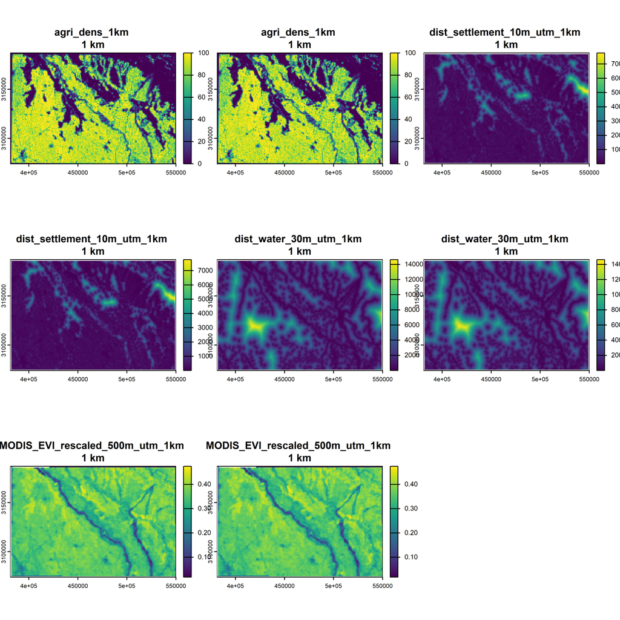

```r
par(mfrow = c(2,2), mar = c(2,2,2,4))

plot(
  rasters,
  main = paste(names(rasters), "\n1 km")
)
```

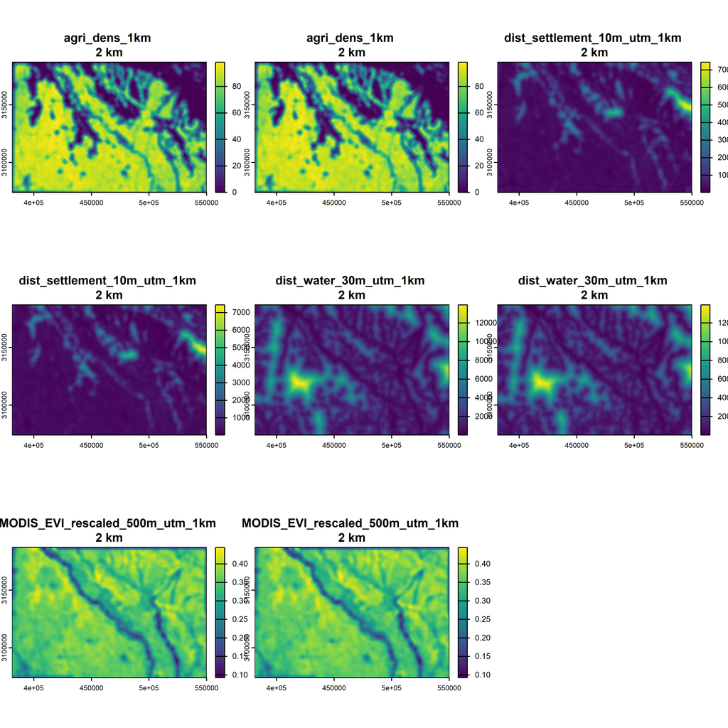

```r
plot(
  rasters_2km,
  main = paste(names(rasters_2km), "\n2 km")
)
```

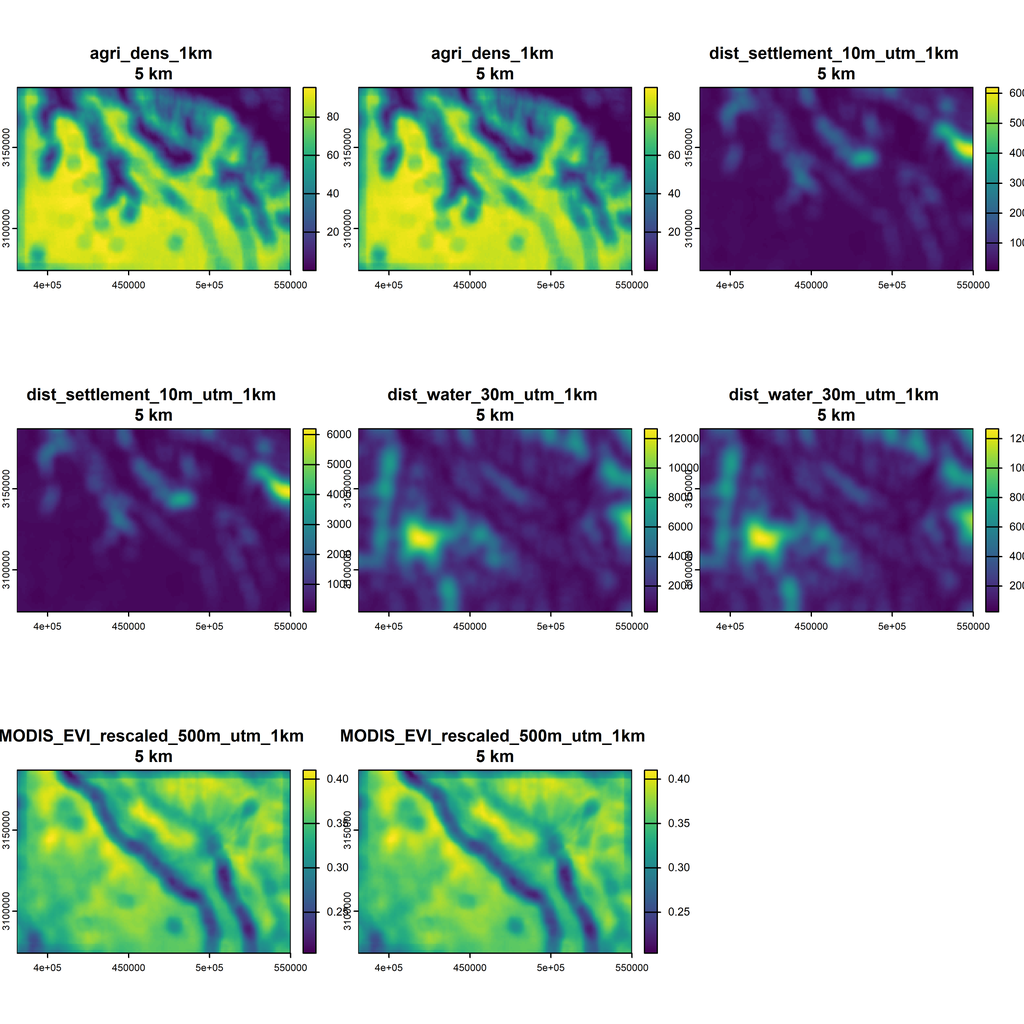

```r
plot(
  rasters_5km,
  main = paste(names(rasters_5km), "\n5 km")
)
```

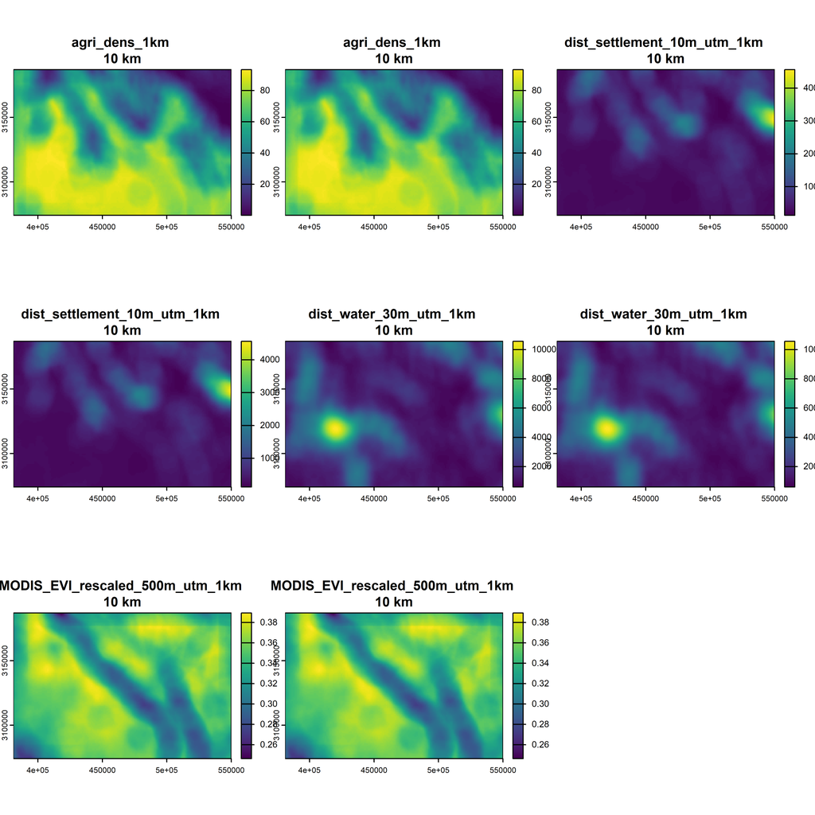

```r
plot(
  rasters_10km,
  main = paste(names(rasters_10km), "\n10 km")
)
```

```r
par(mfrow = c(1,1))
```

# 4 Export raster surfaces

Raster stacks from each spatial scale are exported as ASCII grids for use in subsequent resistance surface optimization analyses. Create a ./input/smooth folder for storing these processed layers of at multiple scales all with a resolution of 1km.

```r
raster_list <- list(
  "1km" = rasters,
  "2km" = rasters_2km,
  "5km" = rasters_5km,
  "10km" = rasters_10km
)

base_dir <- "./input/smooth"

for(scale_name in names(raster_list)) {

  r_stack <- raster_list[[scale_name]]

  out_dir <- file.path(
    base_dir,
    paste0("rasters_", scale_name)
  )

  ## Create output directory if it does not already exist
  if(!dir.exists(out_dir)){

    dir.create(
      out_dir,
      recursive = TRUE,
      showWarnings = FALSE
    )

  }

  for(i in 1:nlyr(r_stack)) {

    writeRaster(

      r_stack[[i]],

      filename = file.path(
        out_dir,
        paste0(
          names(r_stack)[i],
          "_",
          scale_name,
          ".asc"
        )
      ),

      overwrite = TRUE,

      filetype = "AAIGrid"

    )

  }

}
```